# Executive Summary: L02 More Models

Data Science 3 with R (STAT 301-3)

Author

Alani Cox-Caceres

## Github Repo Link

https://github.com/STAT301-3-2023SP/L02-more-models-alanicc

## Goal

The goal of this lab is to predict whether or not a wildfire will reach the wildlife protection zone of a national park.

## Dataset

This summary utilizes the `wildfires.csv` dataset contained in the **data** subdirectory. this data comes from a population of 500 wildfires within that park. The dataset has 16 variables in total, but I only observed 14 with the target variable being wlf (variable determining whether or not the fire reached the protection zone).

## Models

To analyze this data, I used 8 different models: k-nearest, random forest, boosted tree, elastic net with two-way interactions, radial support vector machine, polynomial support vector machine, single layer neural network, and a multivariate adaptive regression spline model.

I split the data into a 20/80 split with the training data being the majority, and stratified the `wlf` variable to maintain balance. I used a v-fold cross-validation with 5 folds and repeated them 3 times. In this v-fold cross-validation, the data was split into 5 folds and the procedure was repeated 3 times. Ultimately, this model evaluation method reports the mean result across all folds from all runs. The metric I used to test accuracy was roc_auc, and I performed a confusion matrix on the best final model. A roc_auc score determines how efficient the model is, and a confusion matrix is a table that displays the numerous outcomes of the predictions and results from the dataset.

## Model Performance

The best performance metric and runtimes for each model are shown below:

| model | roc_auc | runtime |
| --- | --- | --- |
| boost | 0.8626924 | 217.744 |
| elastic net | 0.8790664 | 12.166 |
| knn | 0.7679636 | 7.497 |
| mars | 0.8902129 | 16.371 |
| mlp | 0.8590273 | 45.017 |
| random forest | 0.8742524 | 51.224 |
| polynomial svm | 0.8809990 | 100.511 |
| radial svm | 0.8648992 | 41.523 |

Here are the same results displayed as a graph:

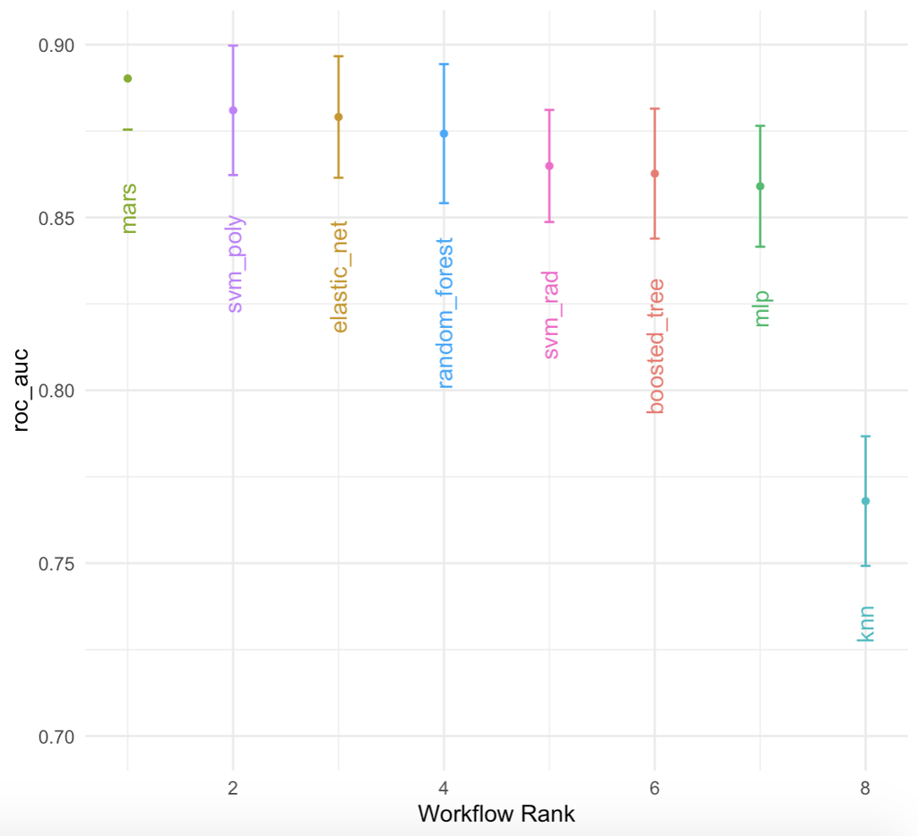

| num_terms | prod_degree | .metric | .estimator | mean | n | std_err | .config |
| --- | --- | --- | --- | --- | --- | --- | --- |
| 8 | 1 | roc_auc | binary | 0.8902129 | 15 | 0.0089966 | Preprocessor1_Model03 |
| 11 | 1 | roc_auc | binary | 0.8837395 | 15 | 0.0097462 | Preprocessor1_Model04 |
| 11 | 2 | roc_auc | binary | 0.8828374 | 15 | 0.0085136 | Preprocessor1_Model09 |
| 8 | 2 | roc_auc | binary | 0.8816146 | 15 | 0.0077468 | Preprocessor1_Model08 |
| 15 | 1 | roc_auc | binary | 0.8811328 | 15 | 0.0088629 | Preprocessor1_Model05 |

This table displays the best metrics that were found for the mars model.

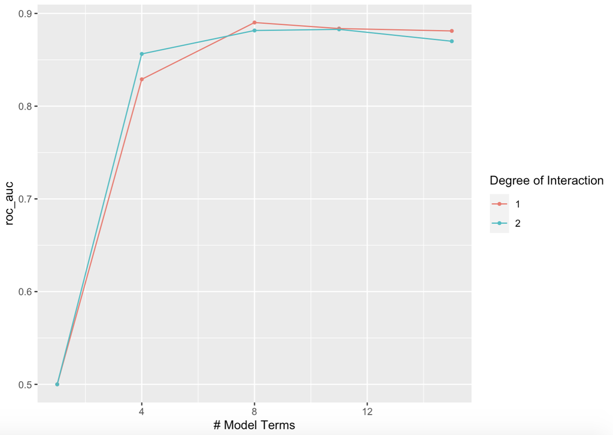

This graph visualizes the roc_auc curve for the mars model. Overall, it seems the model performed relatively well.

Finally, I used this model to create a confusion matrix of the resulting predictions:

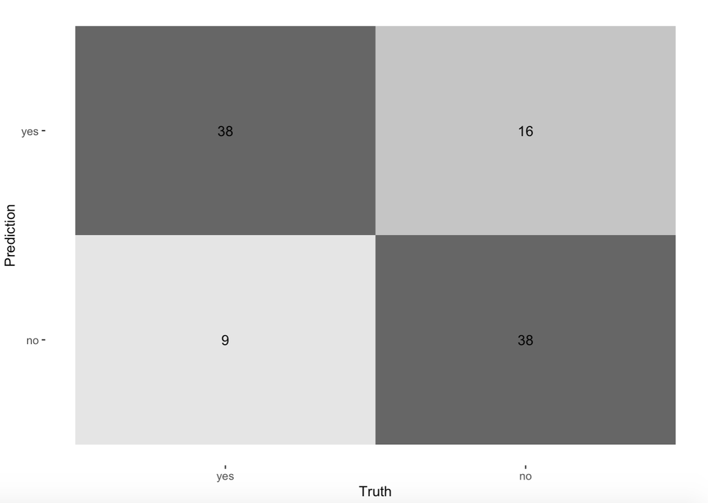

Although these are not the best results, I am still happy with how the model performed and it was able to create relatively accurate predictions within a short period of time. In the future, I’d like to spend more time testing different metrics to determine ways to improve the final predictions. Overall, I found that the mars model was effective in predicting the effects of wildfires in national parks, and I am content with my data exploration.

## Github Repo Link

https://github.com/STAT301-3-2023SP/L02-more-models-alanicc